# Bitcoin Price Analysis (2015-2025)

Joshua Culbert

May 2025

# Introduction

This project analyses Bitcoin price trends (2015-2025) using R, focusing on time series, volatility, and Fourier analysis. Data is sourced from Yahoo Finance via `quantmod`.

## Initial Plot

The following plot shows Bitcoin closing prices from 2015 to 2025.

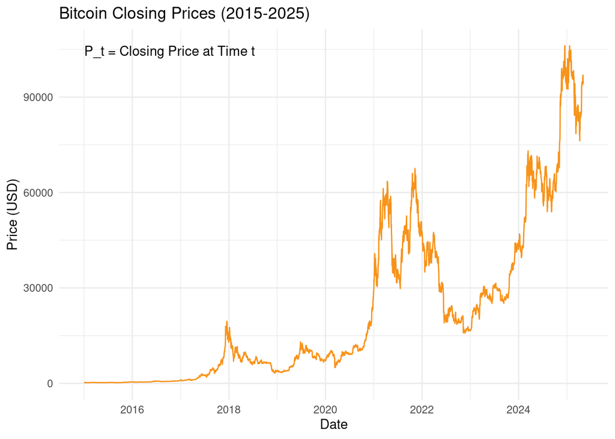

```r
btc_df <- data.frame(Date = index(btc), Price = coredata(btc))
ggplot(btc_df, aes(x = Date, y = BTC.USD.Close)) +
  geom_line(colour = "#F7931A") + # Bitcoin orange
  theme_minimal() +
  labs(title = 'Bitcoin Closing Prices (2015-2025)',
       x = 'Date', y = 'Price (USD)') +
  annotate('text', x = min(btc_df$Date), y = max(btc_df$BTC.USD.Close),
           label = 'P_t = Closing Price at Time t',
           hjust = 0, vjust = 1)
```

## Volatility

Volatility is computed as the 30-day rolling standard deviation of log-returns:
$$\sigma_t = \sqrt{\frac{1}{30} \sum_{i=t-29}^{t} (r_i - \bar{r})^2},
\quad r_i = \log(P_i / P_{i-1})$$

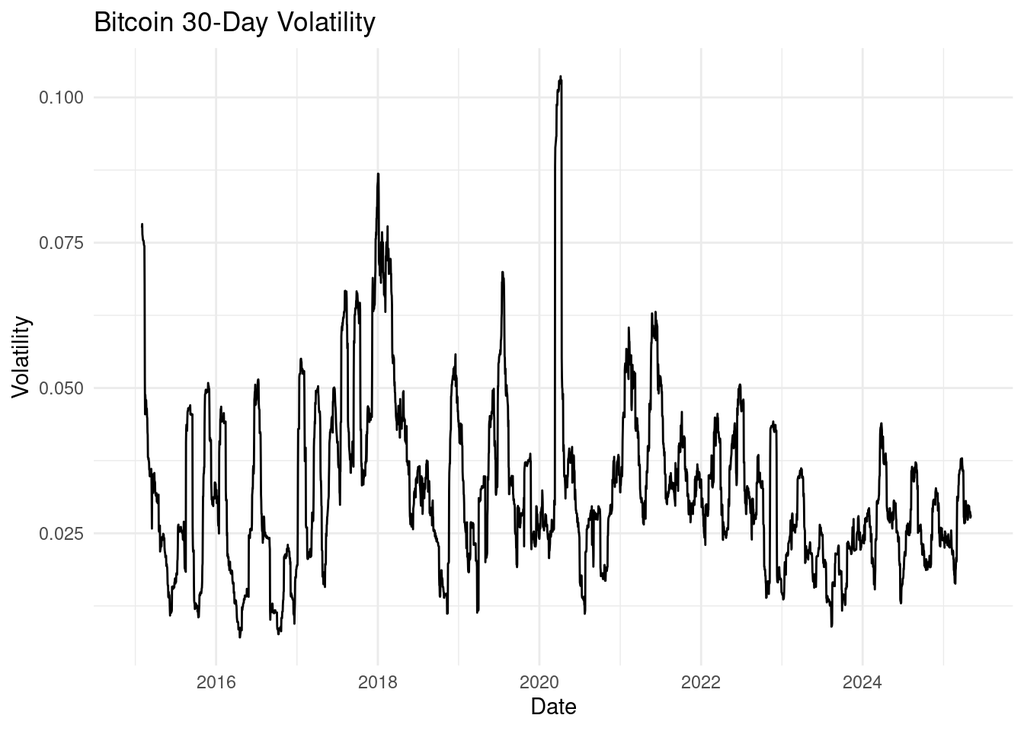

```r
btc_returns <- diff(log(btc))[-1] # Log-returns
btc_volatility <- rollapply(btc_returns, width = 30, FUN = sd,
                            fill = NA, align = 'right')
vol_df <- data.frame(Date = index(btc_volatility),
                     Volatility = coredata(btc_volatility))
ggplot(vol_df, aes(x = Date, y = BTC.USD.Close)) +
  geom_line() +
  theme_minimal() +
  labs(title = 'Bitcoin 30-Day Volatility', x = 'Date', y = 'Volatility')
```

### Volatility by Year

The faceted plot below breaks down volatility by year, highlighting periods of market turbulence.

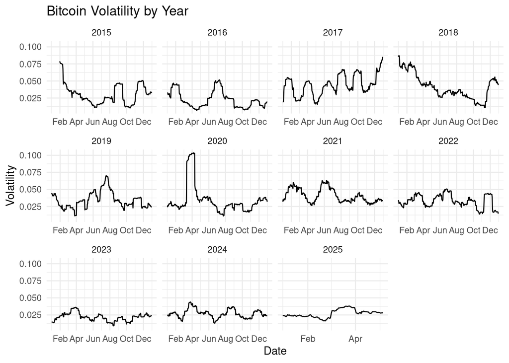

```r
vol_df$Year <- format(vol_df$Date, '%Y')
ggplot(vol_df, aes(x = Date, y = BTC.USD.Close)) +
  geom_line() +
  facet_wrap(~Year, scales = 'free_x') +
  scale_x_date(date_labels = '%b', date_breaks = '2 months') +
  theme_minimal() +
  labs(title = 'Bitcoin Volatility by Year', y = 'Volatility')
```

## Fourier Analysis

The Fast Fourier Transform (FFT) decomposes the detrended price series into frequency components:
$$X_k = \sum_{n=0}^{N-1} x_n e^{-i2\pi kn/N}$$
The power spectrum reveals dominant periodicities.

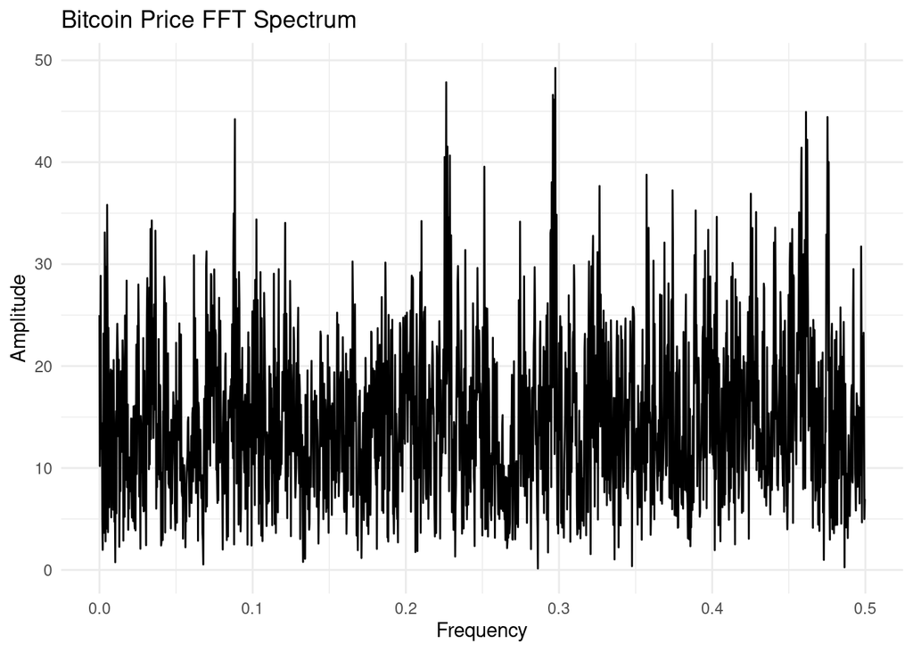

```r
btc_detrended <- diff(btc)[-1] # Remove trend
fft_result <- fft(btc_detrended)
n <- length(btc_detrended)
freq <- (0:(n - 1)) / n # Normalised frequencies
amplitude <- Mod(fft_result) / n # Normalise amplitude
spectrum_df <- data.frame(Frequency = freq[1:(n / 2)],
                          Amplitude = amplitude[1:(n / 2)])
ggplot(spectrum_df, aes(x = Frequency, y = BTC.USD.Close)) +
  geom_line() +
  theme_minimal() +
  labs(title = 'Bitcoin Price FFT Spectrum', x = 'Frequency', y = 'Amplitude')
```